# XArray: the power of pandas for multidimensional arrays

## Introduction to XArray

`xarray.DataArray` is a fancy, labelled version of a `numpy.ndarray`

`xarray.Dataset` is a collection of multiple `DataArray`s which share dimensions

(A `Dataset` is a representation of a NetCDF file)

```python
arr = np.random.rand(3, 4, 2)
```

```python
xr.DataArray(arr)
```

```
<xarray.DataArray (dim_0: 3, dim_1: 4, dim_2: 2)>
array([[[0.006194, 0.380531],
        [0.561032, 0.360739],
        [0.515117, 0.300988],
        [0.650297, 0.560798]],

       [[0.703038, 0.762046],
        [0.703794, 0.467468],
        [0.19292 , 0.395919],
        [0.344915, 0.874793]],

       [[0.570962, 0.881131],
        [0.758426, 0.582632],
        [0.419739, 0.634596],
        [0.720827, 0.12582 ]]])
Dimensions without coordinates: dim_0, dim_1, dim_2
```

```python
xr.DataArray(arr, dims=('x', 'y', 'time'))
```

```
<xarray.DataArray (x: 3, y: 4, time: 2)>
array([[[0.006194, 0.380531],
        [0.561032, 0.360739],
        [0.515117, 0.300988],
        [0.650297, 0.560798]],

       [[0.703038, 0.762046],
        [0.703794, 0.467468],
        [0.19292 , 0.395919],
        [0.344915, 0.874793]],

       [[0.570962, 0.881131],
        [0.758426, 0.582632],
        [0.419739, 0.634596],
        [0.720827, 0.12582 ]]])
Dimensions without coordinates: x, y, time
```

```python
da = xr.DataArray(arr,
                  dims=('x', 'y', 'time'),
                  coords={'x': [10, 20, 30],
                          'y': [0.3, 0.7, 1.3, 1.5],
                          'time': [datetime.datetime(2016, 3, 5),
                                   datetime.datetime(2016, 4, 7)]})
```

```python
da
```

```
<xarray.DataArray (x: 3, y: 4, time: 2)>
array([[[0.006194, 0.380531],
        [0.561032, 0.360739],
        [0.515117, 0.300988],
        [0.650297, 0.560798]],

       [[0.703038, 0.762046],
        [0.703794, 0.467468],
        [0.19292 , 0.395919],
        [0.344915, 0.874793]],

       [[0.570962, 0.881131],
        [0.758426, 0.582632],
        [0.419739, 0.634596],
        [0.720827, 0.12582 ]]])
Coordinates:
  * x        (x) int64 10 20 30
  * y        (y) float64 0.3 0.7 1.3 1.5
  * time     (time) datetime64[ns] 2016-03-05 2016-04-07
```

```python
da.sel(time='2016-03-05')
```

```
<xarray.DataArray (x: 3, y: 4)>
array([[0.006194, 0.561032, 0.515117, 0.650297],
       [0.703038, 0.703794, 0.19292 , 0.344915],
       [0.570962, 0.758426, 0.419739, 0.720827]])
Coordinates:
  * x        (x) int64 10 20 30
  * y        (y) float64 0.3 0.7 1.3 1.5
    time     datetime64[ns] 2016-03-05
```

```python
da.isel(time=1)
```

```
<xarray.DataArray (x: 3, y: 4)>
array([[0.380531, 0.360739, 0.300988, 0.560798],
       [0.762046, 0.467468, 0.395919, 0.874793],
       [0.881131, 0.582632, 0.634596, 0.12582 ]])
Coordinates:
  * x        (x) int64 10 20 30
  * y        (y) float64 0.3 0.7 1.3 1.5
    time     datetime64[ns] 2016-04-07
```

```python
da.sel(x=slice(0, 20))
```

```
<xarray.DataArray (x: 2, y: 4, time: 2)>
array([[[0.006194, 0.380531],
        [0.561032, 0.360739],
        [0.515117, 0.300988],
        [0.650297, 0.560798]],

       [[0.703038, 0.762046],
        [0.703794, 0.467468],
        [0.19292 , 0.395919],
        [0.344915, 0.874793]]])
Coordinates:
  * x        (x) int64 10 20
  * y        (y) float64 0.3 0.7 1.3 1.5
  * time     (time) datetime64[ns] 2016-03-05 2016-04-07
```

```python
da.mean(dim='time')
```

```
<xarray.DataArray (x: 3, y: 4)>
array([[0.193362, 0.460886, 0.408053, 0.605548],
       [0.732542, 0.585631, 0.294419, 0.609854],
       [0.726047, 0.670529, 0.527168, 0.423323]])
Coordinates:
  * x        (x) int64 10 20 30
  * y        (y) float64 0.3 0.7 1.3 1.5
```

```python
da.mean(dim=['x', 'y'])
```

```
<xarray.DataArray (time: 2)>
array([0.512272, 0.527288])
Coordinates:
  * time     (time) datetime64[ns] 2016-03-05 2016-04-07
```

```python
PM25.sel(time='2014').groupby('time.month').std(dim='time')
```

```
<xarray.DataArray 'data' (month: 6, y: 1162, x: 1240)>
array([[[      nan,       nan, ...,       nan,       nan],
        [      nan,       nan, ...,       nan,       nan],
        ...,
        [      nan,       nan, ...,       nan,       nan],
        [      nan,       nan, ...,       nan,       nan]],

       [[      nan,       nan, ...,       nan,       nan],
        [  0.     ,       nan, ...,       nan,       nan],
        ...,
        [      nan,       nan, ...,       nan,       nan],
        [      nan,       nan, ...,       nan,       nan]],

       ...,

       [[ 23.97684,   0.     , ...,       nan,       nan],
        [  1.     ,   2.5    , ...,       nan,       nan],
        ...,
        [      nan,       nan, ...,       nan,       nan],
        [      nan,       nan, ...,       nan,       nan]],

       [[146.48776, 125.04899, ...,       nan,       nan],
        [146.27904, 148.14934, ...,       nan,       nan],
        ...,
        [      nan,       nan, ...,       nan,       nan],
        [      nan,       nan, ...,       nan,       nan]]], dtype=float32)
Coordinates:
  * y        (y) float64 1.429e+06 1.428e+06 1.427e+06 1.426e+06 1.424e+06 ...
  * x        (x) float64 -9.476e+05 -9.464e+05 -9.451e+05 -9.439e+05 ...
  * month    (month) int64 1 2 3 4 5 6
```

## Efficient processing with `dask` and `dask.distributed`

`dask` creates a *computational graph* of your processing steps, and then executes it *as efficiently as possible*.

This includes *only loading data that is actually needed* and *only processing things once*.

```python
data = xr.open_mfdataset(['DaskTest1.nc', 'DaskTest2.nc'], chunks={'time':10})['data']
avg = data.mean(dim='time')
```

```python
seasonal = data.groupby('time.season').mean(dim='time')
```

## `dask.distributed`

All of these different *chunks*, and separate processing chains can be run on **separate processes** or **separate computers**.

[figure not shown]

## Getting data into `xarray`

`xarray` can read various formats directly:

- NetCDF
- HDF
- GRIB

`xarray` can now use `rasterio` to read loads of geographic raster formats

```python
xr.open_rasterio('satellite_image.tif')
```

```
<xarray.DataArray (band: 3, y: 1644, x: 1435)>
[7077420 values with dtype=uint8]
Coordinates:
  * band     (band) int64 1 2 3
  * y        (y) float64 1.484e+05 1.484e+05 1.484e+05 1.484e+05 1.484e+05 ...
  * x        (x) float64 4.301e+05 4.301e+05 4.302e+05 4.302e+05 4.302e+05 ...
Attributes:
    transform:   (10.0, 0.0, 430130.2396, 0.0, -10.0, 148415.8755, 0.0, 0.0, ...
    crs:         +ellps=airy +k=0.999601 +lat_0=49 +lon_0=-2 +no_defs +proj=t...
    res:         (10.0, 10.0)
    is_tiled:    0
    nodatavals:  (nan, nan, nan)
```

## Example - combining multiple satellite data files into a time-series

Take a large number of files, one from each orbit of a satellite, and put them into one large array with a time dimension.

```python
def file_to_da(filename):
    da = xr.open_rasterio(filename)

    time_str = os.path.basename(filename)[17:-17]
    time_obj = datetime.datetime.strptime(time_str, '%Y%j%H%M')
    da.coords['time'] = time_obj

    return da.isel(band=0)
```

```python
list_of_data_arrays = [file_to_da(filename) for filename in files]
```

```python
combined = xr.concat(list_of_data_arrays, dim='time')
```

```python
combined.shape
```

```
(10, 1162, 1240)
```

```python
combined.coords
```

```
Coordinates:
    band     int64 1
  * y        (y) float64 1.429e+06 1.427e+06 1.426e+06 1.425e+06 1.424e+06 ...
  * x        (x) float64 -9.47e+05 -9.458e+05 -9.445e+05 -9.432e+05 ...
  * time     (time) datetime64[ns] 2003-04-16T14:40:00 2002-03-19T11:20:00 ...
```

## Getting raster data out of xarray

```python
from xarray_to_rasterio import xarray_to_rasterio
```

```python
mean = combined.mean(dim='time', keep_attrs=True)
```

```python
xarray_to_rasterio(mean, 'Mean.tif')
```

# A few tasters...

## Interpolation

```python
PM25.interp(x=318193.5, y=176849.7).to_pandas().dropna().head()
```

```
time
2014-01-07    74.390257
2014-01-09    42.588762
2014-01-19    84.464250
2014-02-07    37.803606
2014-02-11    67.395553
dtype: float64
```

```python
PM25.interp(x=318193.5, y=176849.7, method='nearest').to_pandas().dropna().head()
```

```
time
2014-01-07     72.0
2014-01-09     42.0
2014-01-19     82.0
2014-01-27    159.0
2014-02-01    297.0
dtype: float32
```

## Resampling time series

```python
PM25.resample(time='1M').mean(dim='time')
```

```
<xarray.DataArray 'data' (time: 6, y: 1162, x: 1240)>
array([[[       nan,        nan, ...,        nan,        nan],
        [       nan,        nan, ...,        nan,        nan],
        ...,
        [       nan,        nan, ...,        nan,        nan],
        [       nan,        nan, ...,        nan,        nan]],

       [[       nan,        nan, ...,        nan,        nan],
        [ 20.      ,        nan, ...,        nan,        nan],
        ...,
        [       nan,        nan, ...,        nan,        nan],
        [       nan,        nan, ...,        nan,        nan]],

       ...,

       [[ 70.333336,  46.      , ...,        nan,        nan],
        [ 49.      ,  53.5     , ...,        nan,        nan],
        ...,
        [       nan,        nan, ...,        nan,        nan],
        [       nan,        nan, ...,        nan,        nan]],

       [[333.      , 326.5     , ...,        nan,        nan],
        [324.33334 , 334.33334 , ...,        nan,        nan],
        ...,
        [       nan,        nan, ...,        nan,        nan],
        [       nan,        nan, ...,        nan,        nan]]], dtype=float32)
Coordinates:
  * time     (time) datetime64[ns] 2014-01-31 2014-02-28 2014-03-31 ...
  * y        (y) float64 1.429e+06 1.428e+06 1.427e+06 1.426e+06 1.424e+06 ...
  * x        (x) float64 -9.476e+05 -9.464e+05 -9.451e+05 -9.439e+05 ...
```

## Rolling windows

```python
PM25.rolling(time=5).mean()
```

[output not shown]

## OPeNDAP

Accessing data over the internet - **but only downloading the bits you use**

```python
dataset = xr.open_dataset('http://opendap.knmi.nl/knmi/thredds/dodsC/e-obs_0.25regular/tg_0.25deg_reg_v17.0.nc')
```

```python
dataset['tg']
```

```
<xarray.DataArray 'tg' (time: 24837, latitude: 201, longitude: 464)>
[2316397968 values with dtype=float32]
Coordinates:
  * longitude  (longitude) float32 -40.375 -40.125 -39.875 -39.625 -39.375 ...
  * latitude   (latitude) float32 25.375 25.625 25.875 26.125 26.375 26.625 ...
  * time       (time) datetime64[ns] 1950-01-01 1950-01-02 1950-01-03 ...
Attributes:
    long_name:      mean temperature
    units:          Celsius
    standard_name:  air_temperature
```

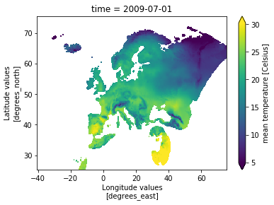

```python
temperature = dataset['tg']
oneday = temperature.sel(time='2009-07-01')
oneday.plot(robust=True)
```

## `xarray` extensions

- Simulation models in xarray (`xarray-simlab`)
- WRF Weather Forecasting Model functions (`wrf-python`)
- Empirical Orthogonal Functions (`eofs`)
- *Many more at* http://xarray.pydata.org/en/stable/faq.html#what-other-projects-leverage-xarray

```python
from eofs.xarray import Eof
monthly = PM25.resample(time='M').mean('time')
solver = Eof(monthly)
results = solver.eofs()
```

[output not shown]

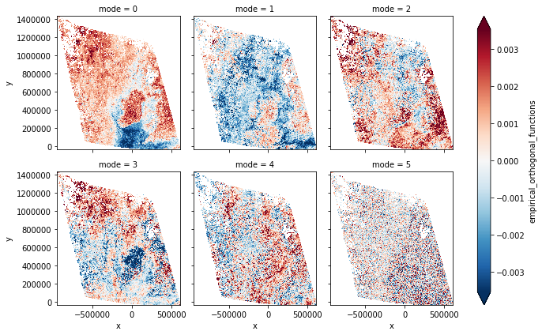

```python
results.plot(col='mode', col_wrap=3, robust=True)
```

# Resources

**Slides:** http://bit.do/xarray_pyconuk

**Code:** https://github.com/robintw/XArray_PyConUK2018

**XArray docs:** http://xarray.pydata.org/

robin@rtwilson.com @sciremotesense @robintw on Slack